# Getting Started with `HydeNet`

## MCMC Inference

MCMC sampling is performed by calling `HydePosterior()`. This function calls `coda.samples()` from the `rjags` library and returns an augmented `mcmc.list` object. MCMC diagnostics and inference from this point onward are performed in the same manner as would typically be done when using `rjags`.

```r
post1 <- HydePosterior(carNet1,
                       variable.names = c("cyl","hp","mpg"),
                       n.iter = 10000,
                       bind=FALSE)

post2 <- HydePosterior(carNet2,
                       variable.names = c("cyl","hp","mpg"),
                       n.iter = 10000,
                       bind = FALSE)

str(post1, max.level = 3)
```

```
## List of 4
##  $ codas    :List of 1
##   ..$ : mcmc [1:10000, 1:3] 2 1 2 2 1 1 1 1 3 2 ...
##   .. ..- attr(*, "dimnames")=List of 2
##   .. ..- attr(*, "mcpar")= num [1:3] 1 10000 1
##   ..- attr(*, "class")= chr "mcmc.list"
##  $ observed : NULL
##  $ dag      :Formal class 'graphNEL' [package "graph"] with 6 slots
##   .. ..@ nodes     : chr [1:6] "cyl" "disp" "hp" "wt" ...
##   .. ..@ edgeL     :List of 6
##   .. ..@ edgeData  :Formal class 'attrData' [package "graph"] with 2 slots
##   .. ..@ nodeData  :Formal class 'attrData' [package "graph"] with 2 slots
##   .. ..@ renderInfo:Formal class 'renderInfo' [package "graph"] with 4 slots
##   .. ..@ graphData :List of 1
##  $ factorRef:List of 3
##   ..$ cyl :'data.frame': 3 obs. of  2 variables:
##   .. ..$ value: int [1:3] 1 2 3
##   .. ..$ label: chr [1:3] "4" "6" "8"
##   ..$ gear:'data.frame': 3 obs. of  2 variables:
##   .. ..$ value: int [1:3] 1 2 3
##   .. ..$ label: chr [1:3] "3" "4" "5"
##   ..$ am  :'data.frame': 2 obs. of  2 variables:
##   .. ..$ value: int [1:2] 1 2
##   .. ..$ label: chr [1:2] "0" "1"
##  - attr(*, "class")= chr "HydePosterior"
```

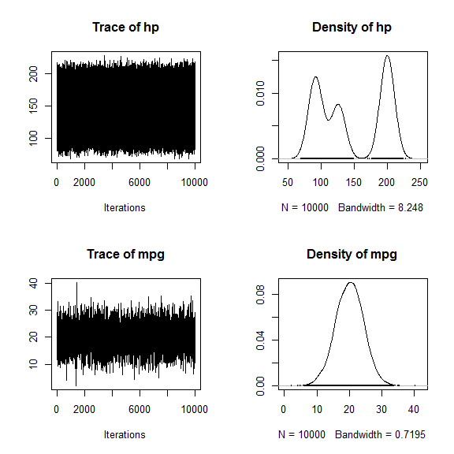

```r
plot(post1$codas[,c("hp","mpg")])
```

We have included a convenience function called `bindPosterior()` than can be used to combine multiple chains’ samples into a single data frame with all factors re-mapped to their original non-numeric values.

Below, we apply the function to obtain posterior densities under each of the two scenarios (no observation of other nodes and after observation of cyl = “8”, respectively):

```r
bp1 <- bindPosterior(post1)
bp2 <- bindPosterior(post2)

head(bp1)
```

```
##   cyl        hp      mpg chain_index obs_index
## 1   6 128.93962 23.69979           1         1
## 2   4  89.04447 28.74537           1         2
## 3   6 130.11889 24.63368           1         3
## 4   6 120.08351 24.26026           1         4
## 5   4 102.65775 15.90820           1         5
## 6   4  92.29817 19.23253           1         6
```

```r
head(bp2) #notice cyl = "8" for all samples
```

```
##   cyl       hp      mpg chain_index obs_index
## 1   8 206.0941 17.26486           1         1
## 2   8 191.9065 15.27753           1         2
## 3   8 221.4858 18.60620           1         3
## 4   8 212.2165 27.01767           1         4
## 5   8 207.1588 20.13701           1         5
## 6   8 195.8688 16.70636           1         6
```

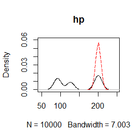

```r
plot(density(bp1$hp), ylim=c(0,0.06), main = "hp");
lines(density(bp2$hp), col="red", lty=5)
```

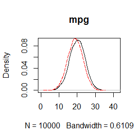

```r
plot(density(bp1$mpg), main = "mpg");
lines(density(bp2$mpg), col="red", lty=5)
```

## Global `HydeNet` Options

There are a couple of global options `HydeNet` establishes that you should be aware of.

### `Hyde_fitModel`

The `Hyde_fitModel` controls the behavior of `setNode` function. If `FALSE`, the model described by the arguments will not be fit until the JAGS model statement is written by `writeNetworkModel`.

The option can be set by using the code below. The default setting is `FALSE`.

```r
options(Hyde_fitModel=FALSE)
```

Realistically, the time spent to fit the model will be spent one way or another, and it’s a matter of preference for where you spend that time. If you wish to do it all at once when calling `writeNetworkModel`, set the option to `FALSE`. Your printed output when reviewing a network will appear as follows:

```
## A Probabilistic Graphical Network
## Has data attached: Yes
##
## treat | d.dimer * angio
## dbern(p = fromData)
## glm: treat ~ poly(d.dimer, 2) + angio
```

If the `Hyde_fitModel` option is set to `TRUE`, the output would appear as follows:

```
## A Probabilistic Graphical Network
## Has data attached: Yes
##
## treat | d.dimer * angio
## dbern(p = treat ~ ilogit(-1.40357 + 1.74183*(angio==2) + 81.96278*d.dimer + -3.60779*d.dimer))
## glm: treat ~ poly(d.dimer, 2) + angio
```

### `Hyde_maxDigits`

This options, set to 5 by default, controls the number of decimal places printed in the JAGS model code. It can be increased or decreased depending on the level of precision you need or want in your estimates.

```r
library(HydeNet)
data(PE, package='HydeNet')
autoNet <- HydeNetwork(~ wells
                       + pe | wells
                       + d.dimer | pregnant*pe
                       + angio | pe
                       + treat | d.dimer*angio
                       + death | pe*treat,
                       data = PE)
writeNetworkModel(autoNet, pretty=TRUE)
```

```
## model{
##    wells ~ dnorm(3.7942, 0.6305)
##    pe ~ dbern(ilogit(-3.90355 + 0.5757 * wells))
##    d.dimer ~ dnorm(210.24251 + 68.37938 * (pe == 2) + 29.29496 * (pregnant == 2), 0.03347)
##    pi.pregnant[1] <- 0.9014; pi.pregnant[2] <- 0.0986
##    pregnant ~ dcat(pi.pregnant)
##    pi.angio <- cpt.angio[(pe+1), ]
##    angio ~ dcat(pi.angio)
##    treat ~ dbern(ilogit(-5.89316 + 1.73354 * (angio == 2) + 0.01994 * d.dimer))
##    pi.death <- cpt.death[(pe+1), (treat+1), ]
##    death ~ dcat(pi.death)
## }
```

If 5 digits is too much for your taste:

```r
library(HydeNet)
options(Hyde_maxDigits=2)
data(PE, package='HydeNet')
autoNet <- HydeNetwork(~ wells
                       + pe | wells
                       + d.dimer | pregnant*pe
                       + angio | pe
                       + treat | d.dimer*angio
                       + death | pe*treat,
                       data = PE)
writeNetworkModel(autoNet, pretty=TRUE)
```

```
## model{
##    wells ~ dnorm(3.79, 0.63)
##    pe ~ dbern(ilogit(-3.9 + 0.58 * wells))
##    d.dimer ~ dnorm(210.24 + 68.38 * (pe == 2) + 29.29 * (pregnant == 2), 0.03)
##    pi.pregnant[1] <- 0.9; pi.pregnant[2] <- 0.1
##    pregnant ~ dcat(pi.pregnant)
##    pi.angio <- cpt.angio[(pe+1), ]
##    angio ~ dcat(pi.angio)
##    treat ~ dbern(ilogit(-5.89 + 1.73 * (angio == 2) + 0.02 * d.dimer))
##    pi.death <- cpt.death[(pe+1), (treat+1), ]
##    death ~ dcat(pi.death)
## }
```

## A Note About Printing

**This note applies to R versions less than 3.2.**

You may notice throughout the vignettes that we tend to call the print function explicitly. That is, we use `print(object)` instead of simply submitting `object` to the console. The `HydeNet` objects can get pretty large, and the implicit printing can become pretty slow as a result. Consider the following comparison:

```r
> #* Object based on a list of models
> g1 <- lm(wells ~ 1, data=PE)
> g2 <- glm(pe ~ wells, data=PE, family="binomial")
> g3 <- lm(d.dimer ~ pe + pregnant, data=PE)
> g4 <- xtabs(~ pregnant, data=PE)
> g5 <- glm(angio ~ pe, data=PE, family="binomial")
> g6 <- glm(treat ~ d.dimer + angio, data=PE, family="binomial")
> g7 <- glm(death ~ pe + treat, data=PE, family="binomial")

> bagOfModels <- list(g1,g2,g3,g4,g5,g6,g7)
> bagNet <- HydeNetwork(bagOfModels)

> #* Time to print bagNet implicitly
> a <- Sys.time()
> bagNet
> b <- Sys.time()
> b-a
Time difference of 33.53736 secs

> #* Time to print bagNet explicitly
> a <- Sys.time()
> print(bagNet)
> b <- Sys.time()
> b-a
Time difference of 0 secs
```